# Cx4073 : Assignment 2

Then, optimised random forest is used to get the best possible model. It is observed that choosing 2 as variable for split will give the optimal result.

```r
trials <- 15               # Number of trials for mtry
nTree <- 500              # Fixing the value of ntree

oobError <- double(trials)
for (mt in 1:trials) {
  rfFit <- randomForest(Subscribed ~ Age+Job+Marital+Education+Default+Housing+Loan+Contact+Month+Day+Duration+Campaign+PrevDays+Previous+PrevOutcome, data = marketTrain, ntree = nTree, mtry = mt)
  oobError[mt] <- rfFit$err.rate[nTree,1]   # OOB MSE after fitting all trees
  cat("Experiment completed with mtry = ", mt, "\n")
}
```

```
## Experiment completed with mtry =  1
## Experiment completed with mtry =  2
## Experiment completed with mtry =  3
## Experiment completed with mtry =  4
## Experiment completed with mtry =  5
## Experiment completed with mtry =  6
## Experiment completed with mtry =  7
## Experiment completed with mtry =  8
## Experiment completed with mtry =  9
## Experiment completed with mtry =  10
## Experiment completed with mtry =  11
## Experiment completed with mtry =  12
## Experiment completed with mtry =  13
## Experiment completed with mtry =  14
## Experiment completed with mtry =  15
```

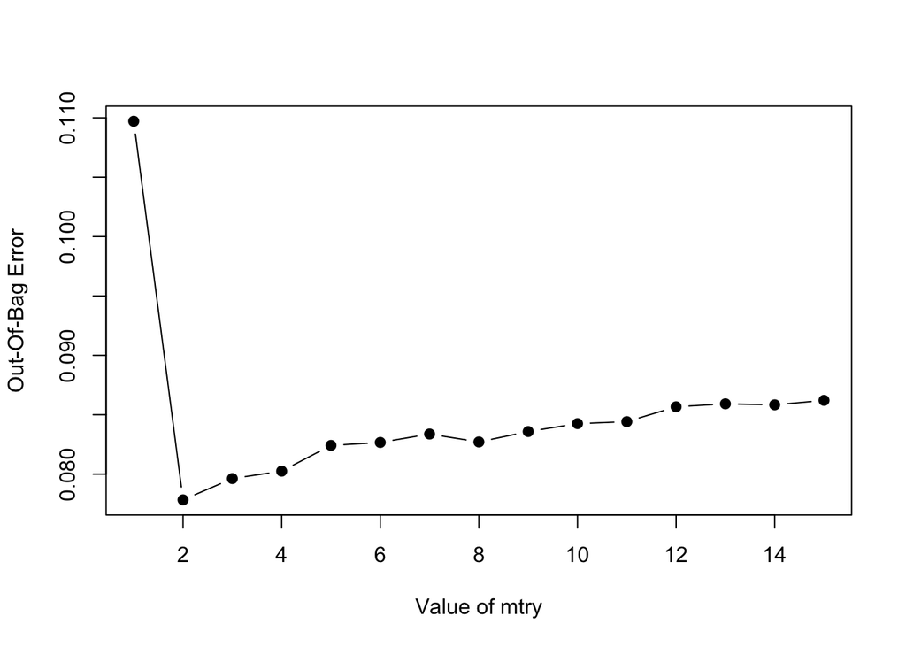

```r
plot(1:trials, oobError, pch=19, type="b",
     xlab = "Value of mtry", ylab = "Out-Of-Bag Error")
```

```r
rfFit <- randomForest(Subscribed ~ Age+Job+Marital+Education+Default+Housing+Loan+Contact+Month+Day+Duration+Campaign+PrevDays+Previous+PrevOutcome, data = marketTrain,
                      ntree = 500, mtry = 2,
                      na.action = na.action(marketTrain),
                      importance = TRUE)
rfFit
```

```
##
## Call:
##  randomForest(formula = Subscribed ~ Age + Job + Marital + Education +      Default + Housing + Loan + Contact + Month + Day + Duration +      Campaign + PrevDays + Previous + PrevOutcome, data = marketTrain,      ntree = 500, mtry = 2, importance = TRUE, na.action = na.action(marketTrain))
##                Type of random forest: classification
##                      Number of trees: 500
## No. of variables tried at each split: 2
##
##         OOB estimate of  error rate: 7.75%
## Confusion matrix:
##        no   yes class.error
## no  10934  1069  0.08906107
## yes   791 11206  0.06593315
```

```r
predTrain <- predict(rfFit, marketTrain, type = "class")  # prediction on train set
mean(predTrain == marketTrain$Subscribed)                       # classification accuracy
```

```
## [1] 0.9937083
```

```r
predValid <- predict(rfFit, marketValid, type = "class")  # prediction on validation set
mean(predValid == marketValid$Subscribed)
```

```
## [1] 0.9196667
```

```r
importance(rfFit)        # importance of the variables in the model (values)
```

```
##                     no       yes MeanDecreaseAccuracy MeanDecreaseGini
## Age          44.481524  27.01576             51.12822        564.11655
## Job          48.353208  33.90231             51.63921        450.15211
## Marital      17.098749  27.35878             31.11611        119.27250
## Education    25.536167  37.01370             42.52611        277.92568
## Default      12.402370  36.22664             36.62561        150.43344
## Housing      10.669364  23.65417             23.93979         86.00321
## Loan          9.096378  23.37929             22.62870         68.69801
## Contact      43.370230  32.75497             47.10685        295.55726
## Month        82.255014  54.81233             84.62618        960.25325
## Day          20.585040  37.38093             39.35429        245.35472
## Duration    123.033833  96.87501            121.43528       2543.29968
## Campaign     14.725158  40.69045             42.46984        492.28906
## PrevDays     94.250870  57.07659             87.88131       2910.46792
## Previous     55.833184  20.89071             62.72592       1449.82365
## PrevOutcome  36.790318 -14.72565             37.40580        377.55090
```

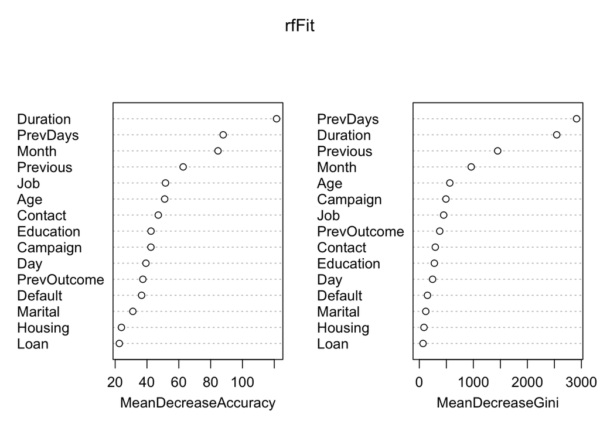

```r
varImpPlot(rfFit)        # importance of the variables in the model (visual)
```

According to this model, Duration, PrevDays and Month are three most important features. Prediction accuracy is improved a lot closing to 0.99 in training set and 0.92 in validation set.

It is observed that people are more likely to subscribe if they are engaged before campaign and engaged again during campaign period.The longer the engagement duration, the more likely people will subscribe the service.

These are the predictions made by using this model.

```r
prediction <- predict(rfFit,predData,type="class")
summary(prediction)
```

```
##  no yes
## 868 132
```

### Decision Tree with Personal Profile, Finanical Profile, Campaign Data and Demographic Info

For this model, all the avaliable features are used.

Simple Decision Tree is made to observe which variables are important.

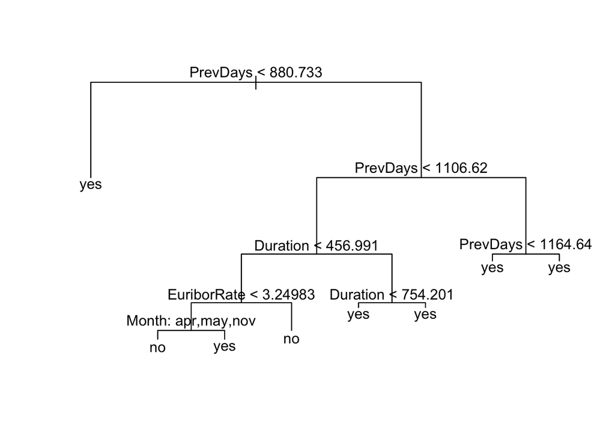

```r
treeFit <- tree(Subscribed ~ ., data = marketTrain)
plot(treeFit)
text(treeFit, pretty = FALSE)
```

```r
summary(treeFit)
```

```
##
## Classification tree:
## tree(formula = Subscribed ~ ., data = marketTrain)
## Variables actually used in tree construction:
## [1] "PrevDays"    "Duration"    "EuriborRate" "Month"
## Number of terminal nodes:  8
## Residual mean deviance:  0.6125 = 14690 / 23990
## Misclassification error rate: 0.133 = 3193 / 24000
```

```r
treeFit
```

```
## node), split, n, deviance, yval, (yprob)
##       * denotes terminal node
##
##  1) root 24000 33270.00 no ( 0.500125 0.499875 )
##    2) PrevDays < 880.733 5530  2394.00 yes ( 0.056239 0.943761 ) *
##    3) PrevDays > 880.733 18470 24280.00 no ( 0.633027 0.366973 )
##      6) PrevDays < 1106.62 15313 17290.00 no ( 0.747861 0.252139 )
##       12) Duration < 456.991 11874  9477.00 no ( 0.863231 0.136769 )
##         24) EuriborRate < 3.24983 4306  5402.00 no ( 0.679517 0.320483 )
##           48) Month: apr,may,nov 2802  2735.00 no ( 0.808708 0.191292 ) *
##           49) Month: aug,dec,jul,jun,mar,oct,sep 1504  2062.00 yes ( 0.438830 0.561170 ) *
##         25) EuriborRate > 3.24983 7568  2156.00 no ( 0.967759 0.032241 ) *
##       13) Duration > 456.991 3439  4451.00 yes ( 0.349520 0.650480 )
##         26) Duration < 754.201 1938  2683.00 yes ( 0.477296 0.522704 ) *
##         27) Duration > 754.201 1501  1436.00 yes ( 0.184544 0.815456 ) *
##      7) PrevDays > 1106.62 3157  1698.00 yes ( 0.076022 0.923978 )
##       14) PrevDays < 1164.64 1097  1135.00 yes ( 0.212397 0.787603 ) *
##       15) PrevDays > 1164.64 2060    93.56 yes ( 0.003398 0.996602 ) *
```

```r
predTrain <- predict(treeFit, marketTrain, type = "class")  # prediction on train set
mean(predTrain == marketTrain$Subscribed)                       # classification accuracy
```

```
## [1] 0.8669583
```

```r
predValid <- predict(treeFit, marketValid, type = "class")  # prediction on validation set
mean(predValid == marketValid$Subscribed)                       # classification accuracy
```

```
## [1] 0.8625
```

“PrevDays”,“Duration”,“EuriborRate”,“Month” were used in simple decision tree. Only one feature becomes important amog all five important features.

Classification accuracy is a little bit more than the previous one in both training and validation sets.

```r
trials <- 20              # Number of trials for mtry
nTree <- 500              # Fixing the value of ntree

oobError <- double(trials)
for (mt in 1:trials) {
  rfFit <- randomForest(Subscribed ~ ., data = marketTrain, ntree = nTree, mtry = mt)
  oobError[mt] <- rfFit$err.rate[nTree,1]   # OOB MSE after fitting all trees
  cat("Experiment completed with mtry = ", mt, "\n")
}
```

```
## Experiment completed with mtry =  1
## Experiment completed with mtry =  2
## Experiment completed with mtry =  3
## Experiment completed with mtry =  4
## Experiment completed with mtry =  5
## Experiment completed with mtry =  6
## Experiment completed with mtry =  7
## Experiment completed with mtry =  8
## Experiment completed with mtry =  9
## Experiment completed with mtry =  10
## Experiment completed with mtry =  11
## Experiment completed with mtry =  12
## Experiment completed with mtry =  13
## Experiment completed with mtry =  14
## Experiment completed with mtry =  15
## Experiment completed with mtry =  16
## Experiment completed with mtry =  17
## Experiment completed with mtry =  18
## Experiment completed with mtry =  19
## Experiment completed with mtry =  20
```

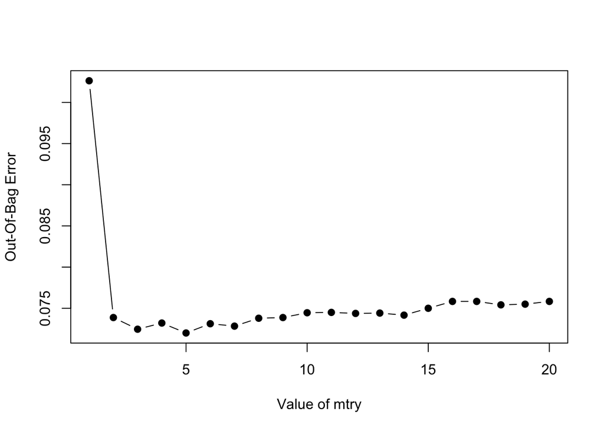

```r
plot(1:trials, oobError, pch=19, type="b",
     xlab = "Value of mtry", ylab = "Out-Of-Bag Error")
```

```r
rfFit <- randomForest(Subscribed ~ ., data = marketTrain,
                      ntree = 500, mtry = 3,
                      na.action = na.action(marketTrain),
                      importance = TRUE)
rfFit
```

```
##
## Call:
##  randomForest(formula = Subscribed ~ ., data = marketTrain, ntree = 500,      mtry = 3, importance = TRUE, na.action = na.action(marketTrain))
##                Type of random forest: classification
##                      Number of trees: 500
## No. of variables tried at each split: 3
##
##         OOB estimate of  error rate: 7.25%
## Confusion matrix:
##        no   yes class.error
## no  10797  1206  0.10047488
## yes   533 11464  0.04442777
```

```r
predTrain <- predict(rfFit, marketTrain, type = "class")  # prediction on train set
mean(predTrain == marketTrain$Subscribed)                       # classification accuracy
```

```
## [1] 1
```

```r
predValid <- predict(rfFit, marketValid, type = "class")  # prediction on validation set
mean(predValid == marketValid$Subscribed)
```

```
## [1] 0.923
```

```r
importance(rfFit)        # importance of the variables in the model (values)
```

```
##                        no        yes MeanDecreaseAccuracy MeanDecreaseGini
## Age            36.2133938  12.218948            37.826446        308.21181
## Job            35.5195807  20.687539            39.678473        319.91781
## Marital         7.4660341  14.133828            15.409821         73.50907
## Education      16.7920073  21.517624            26.599223        199.71497
## Default        -0.1005836  21.777217            21.254968         60.19117
## Housing         4.9098769  11.129415            11.406904         53.37930
## Loan            3.8152615   9.357751             9.420189         40.61007
## Contact        14.7147576  19.968185            18.133780        121.02753
## Month          69.7641620  12.362798            72.752792        638.56290
## Day            12.3736004  21.274296            23.378187        180.29333
## Duration      174.1066024 123.339998           167.772680       2609.32090
## Campaign        8.3337383  37.558546            35.634335        306.65723
## PrevDays      119.0949110  71.878288           118.232763       2600.73746
## Previous       52.9692487  26.388891            59.496279       1005.46698
## PrevOutcome    21.3067680  -9.256926            20.787039        222.79983
## EmpVarRate     34.4675486   4.368512            36.222540        663.86879
## ConPriceIndex  47.2675665 -18.899664            45.549745        378.68662
## ConConfIndex   57.8656363 -19.544140            56.899650        486.84995
## EuriborRate    36.6792325  15.743873            40.834785        781.22956
## NumEmp         51.0774993   8.995619            54.226207        936.04588
```

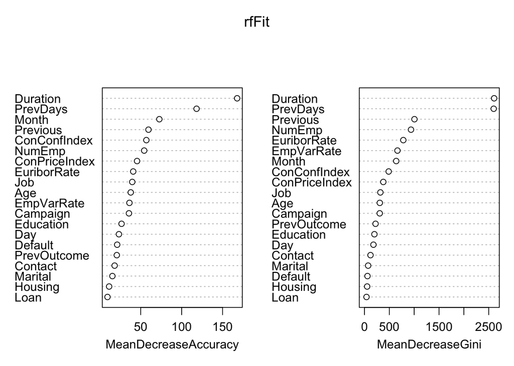

```r
varImpPlot(rfFit)        # importance of the variables in the model (visual)
```

Still, Duration, PrevDays and Month are important features.

Classification accuracy is a little bit more than as the previous model.

These are the predictions made by using this model.

```r
prediction <- predict(rfFit,predData,type="class")
summary(prediction)
```

```
##  no yes
## 888 112
```

### Conclusion

Decision tree’s classification accuracy increses dramatically when features of campaign datas are added.

It is also observed that if we can engage people whom we have engaged before during campaign period, Subscription rate is likely to be increased.

So, bank should engage as many people as it can. Even if, it does not show any effect in short term, it could give long term benefit.